# Airbnb

Project 3: Airbnb Pricing Strategy

By Gaofeng Huang

Class: DATS6103 Data Mining (19Spring) of 15:30-18:00, Thursday.

Source 1: Airbnb Listings  
[Source 2: World Bank Tourists Arrivals](https://data.worldbank.org/indicator/ST.INT.ARVL)  
[Source 3: Hotels Data From GitHub](https://github.com/lucasmonteiro001/free-world-hotel-database/blob/master/hotels.csv.zip)

## Publication

Github: [https://github.com/GH920/DATS-6103-Individual-Project-3]

Zenodo: [https://sandbox.zenodo.org/record/280575#.XM4-CJNKiqA]

```python
import pandas as pd
import numpy as np
import matplotlib.pyplot as pp
import seaborn as sns
import csv
```

```python
import plotly
import plotly.plotly as py
from plotly.graph_objs import *
py.sign_in('ghuang920','8iaLjzlhEXT9N0gAYZ1O')
```

```python
#colorscale made for plotting
scale1 = [[0.0, 'rgb(0,100,0)'],[0.2, 'rgb(34,139,34)'],
         [0.4, 'rgb(60,179,60)'],[0.6, 'rgb(173,255,47)'],
         [0.8, 'rgb(255,215,0)'],[1.0, 'rgb(255,99,71)']]
scale2 = [
          [0.0, "rgb(242,240,247)"],
          [0.2, "rgb(218,218,235)"],
          [0.4, "rgb(188,189,220)"],
          [0.6, "rgb(158,154,200)"],
          [0.8, "rgb(117,107,177)"],
          [1.0, "rgb(84,39,143)"]
      ]
```

```python
sns.set(rc={'figure.figsize':(12,8)})
```

```python
# Due to some reason about the data itself, we only choose these 13 countries to analyze
countries = ['Australia', 'Austria', 'Belgium', 'Canada',
             'France', 'Germany', 'Greece', 'Ireland', 'Italy',
             'Netherlands', 'Spain', 'United Kingdom', 'United States']
```

## Dataset of tourists inflow

```python
# World Bank data, travel inflow by country
travel_raw = pd.read_csv('TravelNumber.csv', skiprows=3)
```

```python
# Get the information about the countries
meta = pd.read_csv('Meta_Country.csv')
```

```python
meta.head()
```

|  | Country Code | Region | IncomeGroup | SpecialNotes | TableName | Unnamed: 5 |
| --- | --- | --- | --- | --- | --- | --- |
| 0 | ABW | Latin America & Caribbean | High income | Central Bureau of Statistics and Central Bank ... | Aruba | NaN |
| 1 | AFG | South Asia | Low income | Central Statistics Organization; World Bank st... | Afghanistan | NaN |
| 2 | AGO | Sub-Saharan Africa | Lower middle income | IMF ; Source of population estimates: UN Popul... | Angola | NaN |
| 3 | ALB | Europe & Central Asia | Upper middle income | Albanian Institute of Statistics ; Source of p... | Albania | NaN |
| 4 | AND | Europe & Central Asia | High income | Government of Andorra, Department of Statistic... | Andorra | NaN |

```python
metaOut = meta.loc[:,['Country Code', 'Region', 'IncomeGroup']]
```

```python
travel_toclean = travel_raw.merge(metaOut, on='Country Code')
```

```python
years = ['2012','2013','2014','2015','2016','2017']
travel = travel_toclean.loc[:, ['Country Name', 'Country Code', 'Region', 'IncomeGroup'] + years]
travel.head(10)
```

|  | Country Name | Country Code | Region | IncomeGroup | 2012 | 2013 | 2014 | 2015 | 2016 | 2017 |
| --- | --- | --- | --- | --- | --- | --- | --- | --- | --- | --- |
| 0 | Aruba | ABW | Latin America & Caribbean | High income | 9.040000e+05 | 9.790000e+05 | 1.072000e+06 | 1.225000e+06 | 1.102000e+06 | 1.070500e+06 |
| 1 | Afghanistan | AFG | South Asia | Low income | NaN | NaN | NaN | NaN | NaN | NaN |
| 2 | Angola | AGO | Sub-Saharan Africa | Lower middle income | 5.280000e+05 | 6.500000e+05 | 5.950000e+05 | 5.920000e+05 | 3.970000e+05 | 2.610000e+05 |
| 3 | Albania | ALB | Europe & Central Asia | Upper middle income | 3.156000e+06 | 2.857000e+06 | 3.341000e+06 | 3.784000e+06 | 4.070000e+06 | 4.643000e+06 |
| 4 | Andorra | AND | Europe & Central Asia | High income | 2.238000e+06 | 2.328000e+06 | 2.363000e+06 | 2.663000e+06 | 2.831000e+06 | NaN |
| 5 | Arab World | ARB | NaN | NaN | 7.899196e+07 | 7.869716e+07 | 8.415708e+07 | 7.885381e+07 | 7.636341e+07 | 8.221460e+07 |
| 6 | United Arab Emirates | ARE | Middle East & North Africa | High income | NaN | NaN | NaN | NaN | NaN | NaN |
| 7 | Argentina | ARG | Latin America & Caribbean | High income | 5.587000e+06 | 5.246000e+06 | 5.931000e+06 | 5.736000e+06 | 6.655000e+06 | 6.720000e+06 |
| 8 | Armenia | ARM | Europe & Central Asia | Upper middle income | 9.630000e+05 | 1.084000e+06 | 1.204000e+06 | 1.192000e+06 | 1.260000e+06 | 1.495000e+06 |
| 9 | American Samoa | ASM | East Asia & Pacific | Upper middle income | 2.260000e+04 | 2.080000e+04 | 2.160000e+04 | 2.030000e+04 | 2.010000e+04 | 2.000000e+04 |

```python
def travelinmap(dataset, year):

    trace1 = dict(
                  z=dataset[year],
                  autocolorscale=False,
                  colorbar={"title": "Tourists Inflow"},
                  colorscale=scale2,
                  locations=dataset['Country Code'],
                  marker=dict(line=dict(color="rgb(180,180,180)",
                                        width=0.5)),
                  reversescale=False,
                  text=dataset['Country Name'],
                  type="choropleth",
                  zmax=10**8,
                  zmin=10**4
    )
    data = [trace1]

    layout = dict(
                  geo=dict(projection={"type": "Mercator"},
                           showcoastlines=True,
                           showframe=True,
                           #showland=True,
                           #landcolor='rgb(220,220,220)'
                  ),
                  title="World Map of Tourists Inflow"
    )
    fig = dict(data=data, layout=layout)
    return py.iplot(fig, validate=False, filename='travel')
```

```python
travelinmap(travel, '2015')
```

[interactive chart not shown]

## Dataset of Airbnb listings

To note that this dataset is not the raw dataset. The raw dataset (about 2GB) can be downloaded in the link showed in the beginning part. This dataset of Airbnb is only 100MB+.

```python
airbnb_rawdata = pd.read_csv('airbnb.csv', sep=';')
```

```python
airbnb_rawdata.head()
```

|  | Unnamed: 0 | ID | Last Scraped | Name | Host ID | Host Response Time | Host Response Rate | Host Acceptance Rate | Host Listings Count | Host Total Listings Count | ... | Review Scores Rating | Review Scores Accuracy | Review Scores Cleanliness | Review Scores Checkin | Review Scores Communication | Review Scores Location | Review Scores Value | Cancellation Policy | Calculated host listings count | Reviews per Month |
| --- | --- | --- | --- | --- | --- | --- | --- | --- | --- | --- | --- | --- | --- | --- | --- | --- | --- | --- | --- | --- | --- |
| 0 | 0 | 2501888 | 2017-03-07 | Private bed in home | 12806524 | within an hour | 100.0 | NaN | 2.0 | 2.0 | ... | 94.0 | 10.0 | 9.0 | 10.0 | 10.0 | 9.0 | 9.0 | flexible | 1.0 | 2.42 |
| 1 | 1 | 377609 | 2017-03-07 | Lake House minutes to Downtown | 1897470 | within a few hours | 100.0 | NaN | 1.0 | 1.0 | ... | 96.0 | 9.0 | 9.0 | 10.0 | 10.0 | 10.0 | 9.0 | strict | 1.0 | 0.54 |
| 2 | 2 | 15643010 | 2017-03-07 | Modern New Apartment Close to Everything! | 59461475 | within an hour | 100.0 | NaN | 1.0 | 1.0 | ... | 97.0 | 10.0 | 10.0 | 10.0 | 10.0 | 10.0 | 10.0 | moderate | 1.0 | 1.86 |
| 3 | 3 | 2236988 | 2017-03-07 | Austin Waterfront Retreat | 11421571 | NaN | NaN | NaN | 1.0 | 1.0 | ... | 96.0 | 9.0 | 10.0 | 10.0 | 10.0 | 10.0 | 10.0 | strict | 1.0 | 0.21 |
| 4 | 4 | 14788276 | 2017-03-07 | Stay at the Domain's hotest residencial property. | 45591877 | a few days or more | 0.0 | NaN | 1.0 | 1.0 | ... | 93.0 | 9.0 | 9.0 | 10.0 | 10.0 | 10.0 | 9.0 | moderate | 1.0 | 0.69 |

5 rows × 53 columns

```python
# drop the "Unnamed: 0" column
airbnb_raw = airbnb_rawdata.drop(["Unnamed: 0"], axis=1)
```

```python
airbnb_raw.head()
```

|  | ID | Last Scraped | Name | Host ID | Host Response Time | Host Response Rate | Host Acceptance Rate | Host Listings Count | Host Total Listings Count | City | ... | Review Scores Rating | Review Scores Accuracy | Review Scores Cleanliness | Review Scores Checkin | Review Scores Communication | Review Scores Location | Review Scores Value | Cancellation Policy | Calculated host listings count | Reviews per Month |
| --- | --- | --- | --- | --- | --- | --- | --- | --- | --- | --- | --- | --- | --- | --- | --- | --- | --- | --- | --- | --- | --- |
| 0 | 2501888 | 2017-03-07 | Private bed in home | 12806524 | within an hour | 100.0 | NaN | 2.0 | 2.0 | West Lake Hills | ... | 94.0 | 10.0 | 9.0 | 10.0 | 10.0 | 9.0 | 9.0 | flexible | 1.0 | 2.42 |
| 1 | 377609 | 2017-03-07 | Lake House minutes to Downtown | 1897470 | within a few hours | 100.0 | NaN | 1.0 | 1.0 | Austin | ... | 96.0 | 9.0 | 9.0 | 10.0 | 10.0 | 10.0 | 9.0 | strict | 1.0 | 0.54 |
| 2 | 15643010 | 2017-03-07 | Modern New Apartment Close to Everything! | 59461475 | within an hour | 100.0 | NaN | 1.0 | 1.0 | Austin | ... | 97.0 | 10.0 | 10.0 | 10.0 | 10.0 | 10.0 | 10.0 | moderate | 1.0 | 1.86 |
| 3 | 2236988 | 2017-03-07 | Austin Waterfront Retreat | 11421571 | NaN | NaN | NaN | 1.0 | 1.0 | Austin | ... | 96.0 | 9.0 | 10.0 | 10.0 | 10.0 | 10.0 | 10.0 | strict | 1.0 | 0.21 |
| 4 | 14788276 | 2017-03-07 | Stay at the Domain's hotest residencial property. | 45591877 | a few days or more | 0.0 | NaN | 1.0 | 1.0 | Austin | ... | 93.0 | 9.0 | 9.0 | 10.0 | 10.0 | 10.0 | 9.0 | moderate | 1.0 | 0.69 |

5 rows × 52 columns

```python
airbnb_raw.shape
```

```
(494954, 52)
```

```python
airbnb_raw.columns
```

```
Index(['ID', 'Last Scraped', 'Name', 'Host ID', 'Host Response Time',
       'Host Response Rate', 'Host Acceptance Rate', 'Host Listings Count',
       'Host Total Listings Count', 'City', 'State', 'Zipcode', 'Market',
       'Country Code', 'Country', 'Latitude', 'Longitude', 'Property Type',
       'Room Type', 'Accommodates', 'Bathrooms', 'Bedrooms', 'Beds',
       'Bed Type', 'Square Feet', 'Price', 'Weekly Price', 'Monthly Price',
       'Security Deposit', 'Cleaning Fee', 'Guests Included', 'Extra People',
       'Minimum Nights', 'Maximum Nights', 'Calendar Updated',
       'Availability 30', 'Availability 60', 'Availability 90',
       'Availability 365', 'Number of Reviews', 'First Review', 'Last Review',
       'Review Scores Rating', 'Review Scores Accuracy',
       'Review Scores Cleanliness', 'Review Scores Checkin',
       'Review Scores Communication', 'Review Scores Location',
       'Review Scores Value', 'Cancellation Policy',
       'Calculated host listings count', 'Reviews per Month'],
      dtype='object')
```

In order to merge these dataset together, country code is the most suitable variable to be used in the combination of data. However, the code in World Bank data has 3 letters while it has 2 letters in other two datasets. Therefore, we should convert the 2-letter code into 3-letter for consistency.

```python
# 2-letter country codes cannot be recognized by plotly
# so we turn it into 3-letter codes
def countrycode2to3(rawdata, on='Country', code='Country Code'):
    data = rawdata.drop(code, axis=1)
    #get 3 code from World Bank data
    meta_code = travel.loc[:,['Country Name','Country Code']]
    meta_code_tomerge = meta_code.rename(columns={'Country Name': on, 'Country Code': code})

    dataout = data.merge(meta_code_tomerge, on=on)
    return dataout
```

```python
airbnb = countrycode2to3(airbnb_raw)
```

```python
airbnb_priceonly = airbnb.loc[:,['Price', 'Country', 'Country Code']]
airbnb_byprice = airbnb_priceonly.groupby(['Country', 'Country Code'], axis=0).mean()
airbnb_byprice['Count'] = airbnb_priceonly.groupby(['Country', 'Country Code'], axis=0).count()['Price']
airbnb_byprice
```

| Country | Country Code | Price | Count |
| --- | --- | --- | --- |
| Australia | AUS | 165.077177 | 40219 |
| Austria | AUT | 67.076562 | 7889 |
| Belgium | BEL | 68.052057 | 7415 |
| Canada | CAN | 107.010622 | 30692 |
| China | CHN | 320.300000 | 50 |
| Cuba | CUB | 102.000000 | 1 |
| Denmark | DNK | 596.433339 | 16569 |
| France | FRA | 94.431201 | 56505 |
| Germany | DEU | 57.222044 | 20568 |
| Greece | GRC | 52.935767 | 5122 |
| Ireland | IRL | 103.780488 | 6724 |
| Italy | ITA | 93.964180 | 33110 |
| Mexico | MEX | 25.000000 | 2 |
| Netherlands | NLD | 133.993607 | 15173 |
| Spain | ESP | 97.136425 | 45732 |
| Switzerland | CHE | 120.157806 | 2370 |
| United Kingdom | GBR | 93.020880 | 60966 |
| United States | USA | 156.051199 | 132581 |
| Uruguay | URY | 237.000000 | 1 |
| Vanuatu | VUT | 110.000000 | 1 |

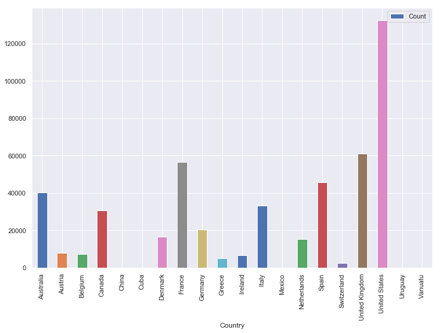

```python
airbnb_byprice.reset_index().plot.bar(x='Country', y='Count')
pp.show()
```

```python
airbnb_byprice_toplot = airbnb_byprice.loc[countries, :].reset_index()
airbnb_byprice_toplot
```

|  | Country | Country Code | Price | Count |
| --- | --- | --- | --- | --- |
| 0 | Australia | AUS | 165.077177 | 40219 |
| 1 | Austria | AUT | 67.076562 | 7889 |
| 2 | Belgium | BEL | 68.052057 | 7415 |
| 3 | Canada | CAN | 107.010622 | 30692 |
| 4 | France | FRA | 94.431201 | 56505 |
| 5 | Germany | DEU | 57.222044 | 20568 |
| 6 | Greece | GRC | 52.935767 | 5122 |
| 7 | Ireland | IRL | 103.780488 | 6724 |
| 8 | Italy | ITA | 93.964180 | 33110 |
| 9 | Netherlands | NLD | 133.993607 | 15173 |
| 10 | Spain | ESP | 97.136425 | 45732 |
| 11 | United Kingdom | GBR | 93.020880 | 60966 |
| 12 | United States | USA | 156.051199 | 132581 |

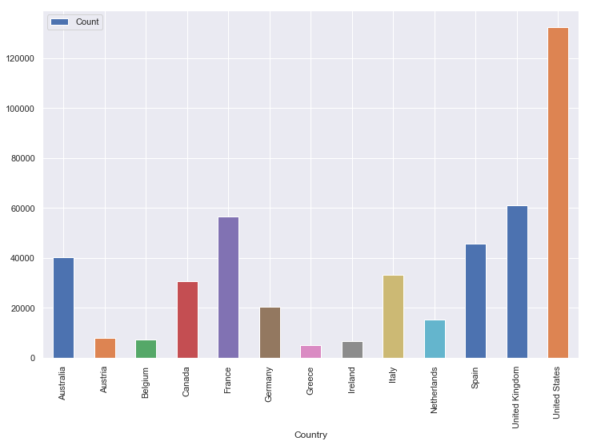

```python
# the observation size w.r.t country
airbnb_byprice_toplot.plot.bar(x='Country', y='Count')
pp.show()
```

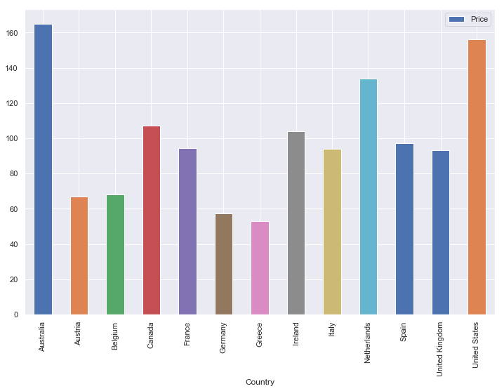

```python
# the average price level of Airbnb w.r.t country
airbnb_byprice_toplot.plot.bar(x='Country', y='Price')
pp.show()
```

### Combine airbnb data with tourists inflow data

```python
airbnb_travel = travel.drop(['2012', '2013', '2014', '2016', '2017'], #only select data in 2015
                axis=1).merge(airbnb_byprice_toplot.drop('Country', axis=1), on='Country Code')
airbnb_travel.rename(columns={'2015': 'TouristsInflow'}, inplace=True)
airbnb_travel
```

|  | Country Name | Country Code | Region | IncomeGroup | TouristsInflow | Price | Count |
| --- | --- | --- | --- | --- | --- | --- | --- |
| 0 | Australia | AUS | East Asia & Pacific | High income | 7450000.0 | 165.077177 | 40219 |
| 1 | Austria | AUT | Europe & Central Asia | High income | 26728000.0 | 67.076562 | 7889 |
| 2 | Belgium | BEL | Europe & Central Asia | High income | 8355000.0 | 68.052057 | 7415 |
| 3 | Canada | CAN | North America | High income | 17971000.0 | 107.010622 | 30692 |
| 4 | Germany | DEU | Europe & Central Asia | High income | 34970000.0 | 57.222044 | 20568 |
| 5 | Spain | ESP | Europe & Central Asia | High income | 68175000.0 | 97.136425 | 45732 |
| 6 | France | FRA | Europe & Central Asia | High income | 84452000.0 | 94.431201 | 56505 |
| 7 | United Kingdom | GBR | Europe & Central Asia | High income | 34436000.0 | 93.020880 | 60966 |
| 8 | Greece | GRC | Europe & Central Asia | High income | 23599000.0 | 52.935767 | 5122 |
| 9 | Ireland | IRL | Europe & Central Asia | High income | 9528000.0 | 103.780488 | 6724 |
| 10 | Italy | ITA | Europe & Central Asia | High income | 50732000.0 | 93.964180 | 33110 |
| 11 | Netherlands | NLD | Europe & Central Asia | High income | 15007000.0 | 133.993607 | 15173 |
| 12 | United States | USA | North America | High income | 77774000.0 | 156.051199 | 132581 |

## Dataset of hotels

There are a lot of problems when we read this dataset. The data is not trivially writen in Comma Seperated Value. It contains quotation and semicolon. Another problem is some values in the column latitude are mixed in the url data.

```python
hotels_rawdata = pd.read_csv('hotels.csv', sep=';', quoting=csv.QUOTE_NONE)
```

```python
hotels_rawdata.head()
```

|  | "hotelName | stars | price | cityName | countryCode | countryName | address | location | url | latitude | longitude" |
| --- | --- | --- | --- | --- | --- | --- | --- | --- | --- | --- | --- |
| 0 | "Fafa Island Resort | 3.0 | 172 | NukuAlofa | TO | Tonga | Fafa Island PO Box 1444 | NukuAlofa Tonga | NaN | -21.0862 | -175.16" |
| 1 | "International Dateline Hotel | 3.0 | 99999 | NukuAlofa | TO | Tonga | P.O.Box 39 Vuna Road | NukuAlofa Tonga | http://www.datelinehotel.com/ | -21.1263 | -175.213" |
| 2 | "Kava Palm Guesthouse NukuAlofa | 2.0 | 99999 | NukuAlofa | TO | Tonga | Taufaa ahau Road | NukuAlofa Tonga | NaN | -21.1599 | -175.229" |
| 3 | "Lagoon Lodge Nuku‘alofa | 3.0 | 99 | NukuAlofa | TO | Tonga | Umusi Road Fanga’uta Lagoon Ma’ufanga | NukuAlofa Tonga | NaN | -21.153 | -175.231" |
| 4 | "Likualofa Beach Resort | 3.0 | 105 | Kanokupolu | TO | Tonga | Private Bag No.2 | Kanokupolu Tonga | NaN | -21.0822 | -175.345" |

```python
hotels_raw = hotels_rawdata.drop('url', axis=1)

# remove the quotation mark in first and last columns
hotels_raw.rename(columns={'"hotelName': 'hotelName', 'longitude"': 'longitude'}, inplace=True)
hotels_raw['hotelName'] = hotels_raw['hotelName'].str.replace('"', '')
hotels_raw['longitude'] = hotels_raw['longitude'].str.replace('"', '')

# 2-letter country codes cannot be recognized by plotly
# so we turn it into 3-letter codes
hotels = countrycode2to3(hotels_raw, on='countryName', code='countryCode')

# remove the NA type value of price==99999
hotels = hotels.loc[hotels.price != 99999, :]
```

```python
def convertNum(x):
    try:
        return np.float(x)
    except:
        print(x)
        return np.nan
```

```python
hotels['latitude'] = hotels['latitude'].apply(convertNum)
hotels['longitude'] = hotels['longitude'].apply(convertNum)
```

```
/Hotel_Review-g293748-d305494-Reviews-Hotel_Sea_Cliff-Dar_es_Salaam.html
/Hotel_Review-g187497-d1153245-Reviews-ME_Barcelona-Barcelona_Catalonia.html
/Hotel_Review-g295371-d2522505-Reviews-Guest_House_Brigita-Dubrovnik_Dubrovnik_Neretva_County_Dalmatia.html
/Hotel_Review-g297586-d1145840-Reviews-Hotel_Padmini_Residency-Hyderabad_Andhra_Pradesh.html
/Hotel_Review-g304555-d1142637-Reviews-Maxima_Resort-Jaipur_Rajasthan.html
/Hotel_Review-g294212-d1159881-Reviews-Jianguo_Hotel-Beijing.html
/Hotel_Review-g303148-d1116545-Reviews-Hotel_Yamaki-Hamamatsu_Shizuoka_Prefecture_Chubu.html
/Hotel_Review-g298031-d1012164-Reviews-Nazar_Garden_Hotel-Fethiye_Mugla_Province_Turkish_Aegean_Coast.html
/VacationRentals-g298019-Reviews-Mugla_Province_Turkish_Aegean_Coast-Vacation_Rentals.html
```

```python
hotels = hotels.dropna(subset = ['stars', 'price', 'latitude', 'longitude'])
```

```python
hotels.countryCode.unique()
```

```
array(['TON', 'FJI', 'WSM', 'ARG', 'CHL', 'NZL', 'AUS', 'URY', 'ZAF',
       'BRA', 'LSO', 'PRY', 'NAM', 'MOZ', 'MDG', 'BWA', 'PYF', 'PRT',
       'ZWE', 'NCL', 'BOL', 'MUS', 'VUT', 'ZMB', 'PER', 'MWI', 'ASM',
       'AGO', 'IDN', 'PNG', 'SLB', 'TZA', 'SYC', 'ECU', 'COL', 'KEN',
       'BDI', 'RWA', 'NLD', 'MEX', 'ITA', 'HRV', 'GAB', 'UGA', 'MDV',
       'GNQ', 'MYS', 'SGP', 'CMR', 'GUY', 'SUR', 'GHA', 'NGA', 'LKA',
       'PHL', 'TGO', 'BEN', 'THA', 'PAN', 'PLW', 'CRI', 'ETH', 'IND',
       'VNM', 'GIN', 'KHM', 'NIC', 'GRD', 'BFA', 'DJI', 'ABW', 'SEN',
       'MLI', 'TCD', 'GTM', 'SLV', 'BRB', 'GUM', 'HND', 'MNP', 'DMA',
       'BLZ', 'SAU', 'OMN', 'MMR', 'JAM', 'DOM', 'PRI', 'HTI', 'MRT',
       'CHN', 'USA', 'CYM', 'CUB', 'TCA', 'BGD', 'ARE', 'QAT', 'PAK',
       'JPN', 'BHR', 'ESP', 'NPL', 'BTN', 'KWT', 'MAR', 'ISR', 'JOR',
       'BMU', 'TUN', 'LBY', 'DZA', 'LBN', 'GRC', 'CYP', 'AFG', 'MLT',
       'GIB', 'TUR', 'TJK', 'ALB', 'ARM', 'AZE', 'UZB', 'CAN', 'FRA',
       'MNE', 'BGR', 'GEO', 'AND', 'XKX', 'SRB', 'KAZ', 'MCO', 'SMR',
       'ROU', 'UKR', 'CHE', 'SVN', 'HUN', 'AUT', 'MDA', 'DEU', 'LIE',
       'MNG', 'CZE', 'GBR', 'BEL', 'LUX', 'POL', 'IRL', 'BLR', 'LTU',
       'DNK', 'SWE', 'LVA', 'EST', 'NOR', 'FIN', 'GRL', 'FRO', 'ISL'],
      dtype=object)
```

```python
hotels.head()
```

|  | hotelName | stars | price | cityName | countryName | address | location | latitude | longitude | countryCode |
| --- | --- | --- | --- | --- | --- | --- | --- | --- | --- | --- |
| 0 | Fafa Island Resort | 3.0 | 172 | NukuAlofa | Tonga | Fafa Island PO Box 1444 | NukuAlofa Tonga | -21.0862 | -175.160 | TON |
| 3 | Lagoon Lodge Nuku‘alofa | 3.0 | 99 | NukuAlofa | Tonga | Umusi Road Fanga’uta Lagoon Ma’ufanga | NukuAlofa Tonga | -21.1530 | -175.231 | TON |
| 4 | Likualofa Beach Resort | 3.0 | 105 | Kanokupolu | Tonga | Private Bag No.2 | Kanokupolu Tonga | -21.0822 | -175.345 | TON |
| 5 | Little Italy Hotel NukuAlofa | 5.0 | 152 | NukuAlofa | Tonga | P.O.Box 2891 Vuna Road Kolomotua | NukuAlofa Tonga | -21.1343 | -175.196 | TON |
| 6 | Loumaile Lodge | 4.0 | 168 | NukuAlofa | Tonga | Taufa’ahau Road | NukuAlofa Tonga | -21.1361 | -175.202 | TON |

```python
hotels_forcity = hotels.drop(['hotelName','address', 'location'], axis=1)
```

```python
hotels_forcity.head(10)
```

|  | stars | price | cityName | countryName | latitude | longitude | countryCode |
| --- | --- | --- | --- | --- | --- | --- | --- |
| 0 | 3.0 | 172 | NukuAlofa | Tonga | -21.0862 | -175.160 | TON |
| 3 | 3.0 | 99 | NukuAlofa | Tonga | -21.1530 | -175.231 | TON |
| 4 | 3.0 | 105 | Kanokupolu | Tonga | -21.0822 | -175.345 | TON |
| 5 | 5.0 | 152 | NukuAlofa | Tonga | -21.1343 | -175.196 | TON |
| 6 | 4.0 | 168 | NukuAlofa | Tonga | -21.1361 | -175.202 | TON |
| 11 | 4.0 | 173 | NukuAlofa | Tonga | -21.1237 | -175.223 | TON |
| 12 | 0.0 | 132 | Kanokupolu | Tonga | -21.0740 | -175.338 | TON |
| 13 | 3.0 | 169 | NukuAlofa | Tonga | -21.1263 | -175.213 | TON |
| 14 | 4.0 | 149 | Lotofoa | Tonga | -19.7236 | -174.286 | TON |
| 19 | 3.0 | 197 | Waiyevo | Fiji | -16.7833 | -179.983 | FJI |

```python
# hotels data grouped by city
hotels_city = hotels_forcity.groupby(['cityName', 'countryName', 'countryCode'], axis=0).mean()
hotels_city['count'] = hotels_forcity.groupby(['cityName', 'countryName', 'countryCode'], axis=0).count()['price']
hotels_city = hotels_city.reset_index()
```

```python
hotels_city.head()
```

|  | cityName | countryName | countryCode | stars | price | latitude | longitude | count |
| --- | --- | --- | --- | --- | --- | --- | --- | --- |
| 0 | 100 Mile House | Canada | CAN | 2.50000 | 97.50000 | 51.630200 | -121.300500 | 2 |
| 1 | 108 Mile Ranch | Canada | CAN | 4.00000 | 183.00000 | 51.733600 | -121.330000 | 1 |
| 2 | A Arnoia | Spain | ESP | 3.00000 | 90.00000 | 42.253200 | -8.135950 | 1 |
| 3 | A Capela | Spain | ESP | 3.00000 | 133.00000 | 43.430200 | -8.063450 | 1 |
| 4 | A Coruna | Spain | ESP | 2.65625 | 50.21875 | 43.358356 | -8.408819 | 32 |

```python
def worldscatter(hotels):
    #data
    data = [dict(type='scattergeo',
                 lat=hotels['latitude'],
                 lon=hotels['longitude'],
                 marker=dict(
                     autocolorscale=False,
                     cmax=300,
                     cmin=0,
                     color= hotels['price'],
                     colorbar=dict(title="Price"),
                     colorscale=scale2,
                     opacity=hotels['price']/200,
                     size=8
                 ),

                 text=('City: ' + hotels['cityName'] +
                       '<br>Country: ' + hotels['countryName'] +
                       '<br>Price: $' + hotels['price'].astype(str)),
                 mode='markers',
                )]

    #layout
    layout = dict(showlegend=False,
                  title= 'Hotel Price by City' + '<br> Hover for value',
                  autosize=True,
                  hovermode='closest',
#                   mapbox=dict(accesstoken='pk.eyJ1IjoidmVubGFoIiwiYSI6ImNqZ2dlMXl5ajVhbWMyd2tsNjFmNHMxMzYifQ.uatR8hT0ddRPxvEyt8CI9g',
#                               bearing=0,
#                               center=dict(lat=str(hotels.latitude.mean()),
#                                           lon=str(hotels.longitude.mean())
#                               )
#                   ),
                  pitch=0,
                  style='light',
                  zoom=3,
                  geo=dict(projection=dict(type='orthographic'), #Mercator
                           scope='world',
                           showlakes=True,
                           showland=True,
                           lakecolor='rgb(95,145,237)',
                           landcolor='rgb(220,220,220)',
                          )
                 )

    fig = dict(data=data, layout=layout)
    return py.iplot(fig, validate=False, filename='scatterhotels')
```

```python
#only plot the city with more than 10 hotels
hotels_cityover10 = hotels_city.loc[hotels_city['count'] > 10, :]
```

```python
hotels_cityover10.head()
```

|  | cityName | countryName | countryCode | stars | price | latitude | longitude | count |
| --- | --- | --- | --- | --- | --- | --- | --- | --- |
| 4 | A Coruna | Spain | ESP | 2.656250 | 50.218750 | 43.358356 | -8.408819 | 32 |
| 12 | Aachen | Germany | DEU | 3.073529 | 85.882353 | 50.764356 | 6.100683 | 34 |
| 15 | Aalborg | Denmark | DNK | 3.142857 | 117.571429 | 57.042714 | 9.917925 | 14 |
| 24 | Aarhus | Denmark | DNK | 2.950000 | 133.100000 | 56.091285 | 10.207155 | 20 |
| 30 | Abano Terme | Italy | ITA | 3.781250 | 92.468750 | 45.352228 | 11.781609 | 32 |

```python
worldscatter(hotels_cityover10)
```

[interactive chart not shown]

## Combine Airbnb, Hotels, Tourists Inflow three datasets together

```python
# hotels grouped by country
hotels_bycountry = hotels_city.drop(['latitude','longitude', 'count']
                     ,axis=1).groupby(['countryName', 'countryCode']).mean(numeric_only=True)
hotels_bycountry['count'] = hotels_city.drop(['latitude','longitude', 'stars', 'price']
                              ,axis=1).groupby(['countryName', 'countryCode']).sum()
hotels_bycountry = hotels_bycountry.reset_index().drop(['countryName'], axis=1)
hotels_bycountry = hotels_bycountry.rename(columns={'countryCode': 'Country Code'})

# Combine hotels data into the previous two datasets
airbnb_hotels_travel = airbnb_travel.merge(hotels_bycountry, on='Country Code')
airbnb_hotels_travel.rename(columns={'Price': 'Airbnb Price', 'Count': '# of Airbnb',
                                     'price': 'Hotel Price', 'count': '# of Hotels',
                                     'stars': 'Hotel Stars'}, inplace=True)
```

```python
def showinmap(dataset, val='Airbnb Price', loc='Country Code', name='Country Name', filename='Airbnb'):

    trace1 = dict(
                  z=dataset[val],
                  autocolorscale=False,
                  colorbar={"title": val},
                  colorscale=scale2,
                  locations=dataset[loc],
                  marker=dict(line=dict(color="rgb(180,180,180)",
                                        width=0.5)),
                  reversescale=False,
                  text=dataset[name],
                  type="choropleth",
                  zmin=0
    )
    data = [trace1]

    layout = dict(
                  geo=dict(projection={"type": "Mercator"},
                           showcoastlines=True,
                           showframe=True,
                           #showland=True,
                           #landcolor='rgb(220,220,220)'
                  ),
                  title="World Map of " + val
    )
    fig = dict(data=data, layout=layout)
    return py.iplot(fig, validate=False, filename=filename)
```

```python
showinmap(airbnb_hotels_travel)
```

[interactive chart not shown]

```python
showinmap(airbnb_hotels_travel, val='Hotel Price', filename='Hotels')
```

[interactive chart not shown]

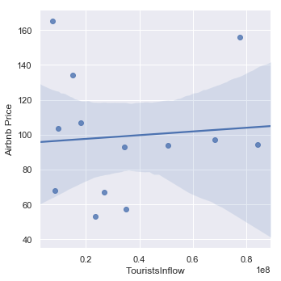

```python
ax = sns.lmplot(data=airbnb_hotels_travel, x='TouristsInflow', y='Airbnb Price')
pp.show()
```

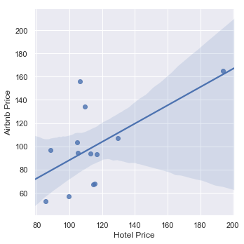

```python
sns.lmplot('Hotel Price', 'Airbnb Price', airbnb_hotels_travel)
pp.show()
```

```python
airbnb_hotels_travel
```

|  | Country Name | Country Code | Region | IncomeGroup | TouristsInflow | Airbnb Price | # of Airbnb | Hotel Stars | Hotel Price | # of Hotels |
| --- | --- | --- | --- | --- | --- | --- | --- | --- | --- | --- |
| 0 | Australia | AUS | East Asia & Pacific | High income | 7450000.0 | 165.077177 | 40219 | 3.665661 | 193.910612 | 4956 |
| 1 | Austria | AUT | Europe & Central Asia | High income | 26728000.0 | 67.076562 | 7889 | 3.013974 | 114.366708 | 5748 |
| 2 | Belgium | BEL | Europe & Central Asia | High income | 8355000.0 | 68.052057 | 7415 | 2.803471 | 115.643554 | 1591 |
| 3 | Canada | CAN | North America | High income | 17971000.0 | 107.010622 | 30692 | 2.752049 | 129.664729 | 3925 |
| 4 | Germany | DEU | Europe & Central Asia | High income | 34970000.0 | 57.222044 | 20568 | 3.007837 | 99.543638 | 13391 |
| 5 | Spain | ESP | Europe & Central Asia | High income | 68175000.0 | 97.136425 | 45732 | 2.666833 | 88.612824 | 12803 |
| 6 | France | FRA | Europe & Central Asia | High income | 84452000.0 | 94.431201 | 56505 | 2.478227 | 104.951777 | 12111 |
| 7 | United Kingdom | GBR | Europe & Central Asia | High income | 34436000.0 | 93.020880 | 60966 | 3.204871 | 116.529650 | 14794 |
| 8 | Greece | GRC | Europe & Central Asia | High income | 23599000.0 | 52.935767 | 5122 | 2.606760 | 85.375987 | 7286 |
| 9 | Ireland | IRL | Europe & Central Asia | High income | 9528000.0 | 103.780488 | 6724 | 3.268726 | 104.791336 | 1206 |
| 10 | Italy | ITA | Europe & Central Asia | High income | 50732000.0 | 93.964180 | 33110 | 2.973318 | 113.031926 | 19884 |
| 11 | Netherlands | NLD | Europe & Central Asia | High income | 15007000.0 | 133.993607 | 15173 | 3.087690 | 109.557754 | 2198 |
| 12 | United States | USA | North America | High income | 77774000.0 | 156.051199 | 132581 | 2.446422 | 106.612129 | 38195 |

[figure not shown]

```python
airbnb_hotels_travel.plot.bar(x='Country Name', y=['Airbnb Price', 'Hotel Price'])
pp.show()
```

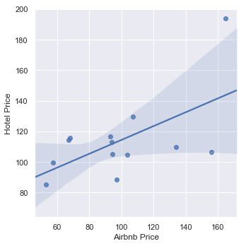

```python
ax = sns.lmplot(data=airbnb_hotels_travel, x='Airbnb Price', y='Hotel Price')
pp.show()
```

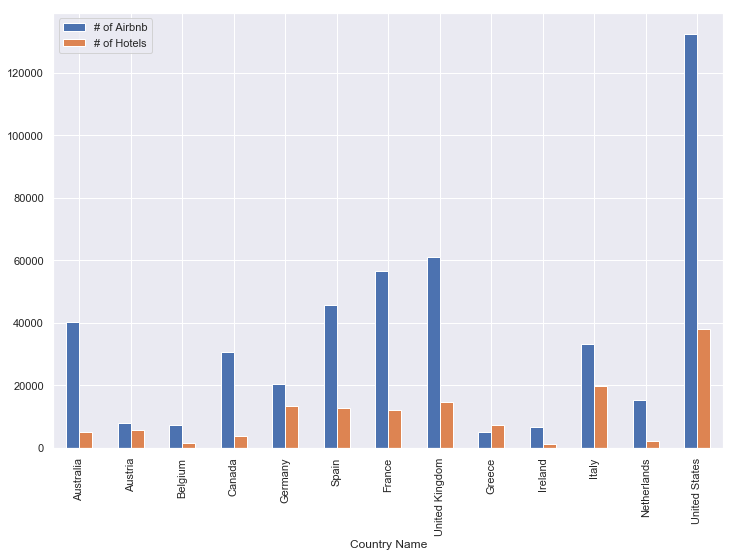

```python
airbnb_hotels_travel.plot.bar(x='Country Name', y=['# of Airbnb', '# of Hotels'])
pp.show()
```

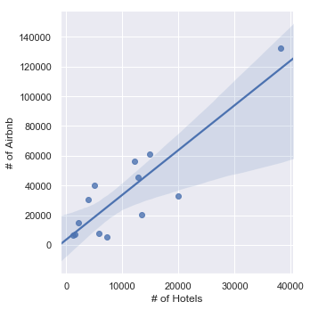

```python
ax = sns.lmplot(data=airbnb_hotels_travel, x='# of Hotels', y='# of Airbnb')
pp.show()
```

### Daily Price -- Weekly Price -- Montly Price?

```python
airbnb_p = airbnb.loc[:, ['City', 'State', 'Country Code', 'Country', 'Latitude', 'Longitude',
                        'Property Type', 'Room Type', 'Bathrooms', 'Bedrooms', 'Beds',
                        'Price', 'Weekly Price', 'Monthly Price',
                        'Availability 30', 'Availability 60', 'Availability 90', 'Availability 365']]
```

```python
airbnb_pricing = airbnb_p.dropna()
airbnb_pricing_plot = airbnb_pricing.groupby(['Country','Country Code']).mean().loc[countries,:].reset_index()
airbnb_pricing_plot['Weekly Price (Ratio)'] = airbnb_pricing_plot['Weekly Price']/airbnb_pricing_plot['Price']
airbnb_pricing_plot['Monthly Price (Ratio)'] = airbnb_pricing_plot['Monthly Price']/airbnb_pricing_plot['Price']
airbnb_pricing_plot['Next Month'] = airbnb_pricing_plot['Availability 60'] - airbnb_pricing_plot['Availability 30']
airbnb_pricing_plot['Next 2nd Month'] = airbnb_pricing_plot['Availability 90'] - airbnb_pricing_plot['Availability 60']
airbnb_pricing_plot
```

|  | Country | Country Code | Latitude | Longitude | Bathrooms | Bedrooms | Beds | Price | Weekly Price | Monthly Price | Availability 30 | Availability 60 | Availability 90 | Availability 365 | Weekly Price (Ratio) | Monthly Price (Ratio) | Next Month | Next 2nd Month |
| --- | --- | --- | --- | --- | --- | --- | --- | --- | --- | --- | --- | --- | --- | --- | --- | --- | --- | --- |
| 0 | Australia | AUS | -35.255923 | 148.579503 | 1.143305 | 1.123466 | 1.413991 | 101.317672 | 581.282955 | 2133.324197 | 10.245106 | 25.514226 | 42.836857 | 190.611851 | 5.737232 | 21.055796 | 15.269120 | 17.322631 |
| 1 | Austria | AUT | 48.206145 | 16.360578 | 1.088804 | 1.134818 | 1.918523 | 63.599648 | 403.174678 | 1271.645955 | 7.908558 | 19.807151 | 34.848769 | 208.286049 | 6.339260 | 19.994544 | 11.898593 | 15.041618 |
| 2 | Belgium | BEL | 50.886356 | 4.370318 | 1.109216 | 1.144823 | 1.693597 | 63.074806 | 382.639138 | 1231.938959 | 8.691801 | 21.588270 | 37.825254 | 206.408139 | 6.066434 | 19.531395 | 12.896469 | 16.236984 |
| 3 | Canada | CAN | 45.508554 | -80.998197 | 1.118675 | 1.187618 | 1.525156 | 79.814412 | 475.785124 | 1541.904596 | 10.295346 | 23.224010 | 37.400464 | 202.018269 | 5.961143 | 19.318624 | 12.928665 | 14.176454 |
| 4 | France | FRA | 48.864023 | 2.348225 | 1.037783 | 0.935244 | 1.546196 | 78.952682 | 506.252702 | 1649.709362 | 7.400979 | 17.191413 | 28.856210 | 174.488476 | 6.412103 | 20.894912 | 9.790434 | 11.664797 |
| 5 | Germany | DEU | 52.509692 | 13.404760 | 1.070305 | 1.175923 | 1.626645 | 55.959551 | 333.784591 | 1052.295666 | 5.021509 | 11.711717 | 19.765971 | 133.834029 | 5.964748 | 18.804577 | 6.690209 | 8.054254 |
| 6 | Greece | GRC | 37.981415 | 23.733592 | 1.135081 | 1.310484 | 2.052419 | 49.975806 | 323.794355 | 1078.937500 | 11.669355 | 28.881048 | 49.016129 | 272.580645 | 6.479022 | 21.589196 | 17.211694 | 20.135081 |
| 7 | Ireland | IRL | 53.345182 | -6.255522 | 1.258310 | 1.286704 | 1.738227 | 83.436288 | 481.063712 | 1663.505540 | 9.189751 | 22.608033 | 38.332410 | 176.288089 | 5.765641 | 19.937435 | 13.418283 | 15.724377 |
| 8 | Italy | ITA | 42.626023 | 12.363507 | 1.176970 | 1.338835 | 2.401121 | 74.491280 | 485.699938 | 1559.972127 | 11.973061 | 28.887730 | 48.825600 | 264.498754 | 6.520225 | 20.941674 | 16.914668 | 19.937870 |
| 9 | Netherlands | NLD | 52.365621 | 4.887895 | 1.052458 | 1.165077 | 1.601614 | 108.778430 | 627.061629 | 2064.720470 | 2.322817 | 7.236977 | 14.302274 | 113.137197 | 5.764577 | 18.980973 | 4.914160 | 7.065297 |
| 10 | Spain | ESP | 40.654117 | -0.838517 | 1.238249 | 1.355661 | 2.050999 | 63.853473 | 397.508658 | 1260.939486 | 8.328449 | 20.654044 | 36.138535 | 224.251951 | 6.225326 | 19.747391 | 12.325595 | 15.484491 |
| 11 | United Kingdom | GBR | 52.216874 | -0.642194 | 1.153336 | 1.180243 | 1.524143 | 69.830446 | 435.758938 | 1556.371176 | 12.777000 | 27.625138 | 44.446369 | 201.544047 | 6.240243 | 22.287860 | 14.848139 | 16.821231 |
| 12 | United States | USA | 38.148298 | -99.842362 | 1.121588 | 1.051515 | 1.397903 | 93.455625 | 567.163644 | 1936.522745 | 10.569079 | 25.022655 | 42.031331 | 211.301500 | 6.068802 | 20.721308 | 14.453576 | 17.008676 |

When we focus on the pricing strategy of Airbnb listings, it is interesting to note that the daily price is competing with the hotels while the monthly price is competing with the property leasing (house rental market).

Daily price is a little bit lower than daily hotel price.  
The range of weekly price is from 5.7 to 6.5 times of daily price. Mainly focus on this section of market.  
The range of monthly price is from 18.8 to 22.3 times of daily price. A little bit higher than monthly leasing price.

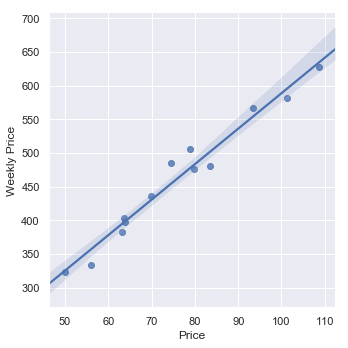

```python
sns.lmplot('Price', 'Weekly Price', airbnb_pricing_plot)
pp.show()
```

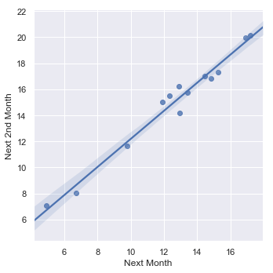

```python
sns.lmplot('Next Month', 'Next 2nd Month', airbnb_pricing_plot)
pp.show()
```

### bedrooms, bathrooms, and beds <-> Price?

We've tried bedrooms, bathrooms, and beds. Afterthat we find the most clear relation is Price ~ Beds, w.r.t Room Type. With more beds, entire apt has a higher price setting, then is Private room, and the lowest price is Shared room.

```python
def airbnbAreaLmplot(by='Country Code', area='USA'):
    airbnb_area = airbnb_pricing.loc[airbnb_p[by]==area, :]
    ax = sns.lmplot(data=airbnb_area, x='Beds', y='Price', hue='Room Type', height=7)
    # ax.set(yscale="log")
    pp.show()
```

### Guess the reason:

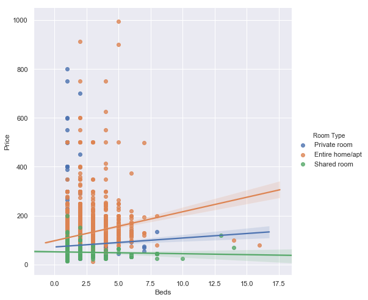

```python
# in the USA
airbnbAreaLmplot()
```

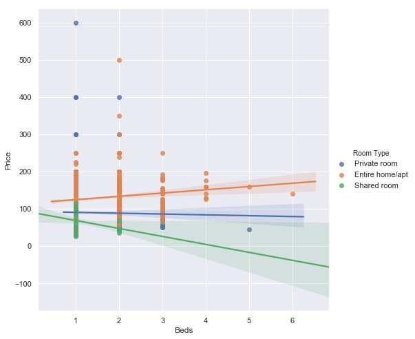

```python
# A particular city
airbnbAreaLmplot('City', 'New York')
```

In the same city, the comparison on the data will be more reasonable. As showed in the data of New York, it is more obvious to see the difference of slope.

```python
# End. Thank you for reading.
```